# Supervised Learning - Foundations Project: ReCell

## Problem Statement

### Business Context

Buying and selling used phones and tablets used to be something that happened on a handful of online marketplace sites. But the used and refurbished device market has grown considerably over the past decade, and a new IDC (International Data Corporation) forecast predicts that the used phone market would be worth \$52.7bn by 2023 with a compound annual growth rate (CAGR) of 13.6% from 2018 to 2023. This growth can be attributed to an uptick in demand for used phones and tablets that offer considerable savings compared with new models.

Refurbished and used devices continue to provide cost-effective alternatives to both consumers and businesses that are looking to save money when purchasing one. There are plenty of other benefits associated with the used device market. Used and refurbished devices can be sold with warranties and can also be insured with proof of purchase. Third-party vendors/platforms, such as Verizon, Amazon, etc., provide attractive offers to customers for refurbished devices. Maximizing the longevity of devices through second-hand trade also reduces their environmental impact and helps in recycling and reducing waste. The impact of the COVID-19 outbreak may further boost this segment as consumers cut back on discretionary spending and buy phones and tablets only for immediate needs.

### Objective

The rising potential of this comparatively under-the-radar market fuels the need for an ML-based solution to develop a dynamic pricing strategy for used and refurbished devices. ReCell, a startup aiming to tap the potential in this market, has hired you as a data scientist. They want you to analyze the data provided and build a linear regression model to predict the price of a used phone/tablet and identify factors that significantly influence it.

### Data Description

The data contains the different attributes of used/refurbished phones and tablets. The data was collected in the year 2021. The detailed data dictionary is given below.

- brand_name: Name of manufacturing brand
- os: OS on which the device runs
- screen_size: Size of the screen in cm
- 4g: Whether 4G is available or not
- 5g: Whether 5G is available or not
- main_camera_mp: Resolution of the rear camera in megapixels
- selfie_camera_mp: Resolution of the front camera in megapixels
- int_memory: Amount of internal memory (ROM) in GB
- ram: Amount of RAM in GB
- battery: Energy capacity of the device battery in mAh
- weight: Weight of the device in grams
- release_year: Year when the device model was released
- days_used: Number of days the used/refurbished device has been used
- normalized_new_price: Normalized price of a new device of the same model in euros
- normalized_used_price: Normalized price of the used/refurbished device in euros

## Importing necessary libraries

```python
# Libraries for reading and manipulating data
import numpy as np
import pandas as pd

# Libraries for data visualization
import matplotlib.pyplot as plt
import seaborn as sns

sns.set()

# to split the data into train and test
from sklearn.model_selection import train_test_split

# to build linear regression_model
from sklearn.linear_model import LinearRegression

# to check model performance
from sklearn.metrics import mean_absolute_error, mean_squared_error, r2_score

# to build linear regression_model using statsmodels
import statsmodels.api as sm

# to compute VIF
from statsmodels.stats.outliers_influence import variance_inflation_factor
```

## Loading the dataset

```python
data=pd.read_csv("/content/drive/MyDrive/Colab Notebooks/used_device_data (2).csv")
```

## Data Overview

- Observations
- Sanity checks

```python
#Checking the data
data.head()
```

|  | brand_name | os | screen_size | 4g | 5g | main_camera_mp | selfie_camera_mp | int_memory | ram | battery | weight | release_year | days_used | normalized_used_price | normalized_new_price |
| --- | --- | --- | --- | --- | --- | --- | --- | --- | --- | --- | --- | --- | --- | --- | --- |
| 0 | Honor | Android | 14.50 | yes | no | 13.0 | 5.0 | 64.0 | 3.0 | 3020.0 | 146.0 | 2020 | 127 | 4.307572 | 4.715100 |
| 1 | Honor | Android | 17.30 | yes | yes | 13.0 | 16.0 | 128.0 | 8.0 | 4300.0 | 213.0 | 2020 | 325 | 5.162097 | 5.519018 |
| 2 | Honor | Android | 16.69 | yes | yes | 13.0 | 8.0 | 128.0 | 8.0 | 4200.0 | 213.0 | 2020 | 162 | 5.111084 | 5.884631 |
| 3 | Honor | Android | 25.50 | yes | yes | 13.0 | 8.0 | 64.0 | 6.0 | 7250.0 | 480.0 | 2020 | 345 | 5.135387 | 5.630961 |
| 4 | Honor | Android | 15.32 | yes | no | 13.0 | 8.0 | 64.0 | 3.0 | 5000.0 | 185.0 | 2020 | 293 | 4.389995 | 4.947837 |

```python
#Checking the shape of the data
data.shape
```

```
(3454, 15)
```

##### The data has 3454 rows and 15 columns

```python
data.info()
```

```
<class 'pandas.core.frame.DataFrame'>
RangeIndex: 3454 entries, 0 to 3453
Data columns (total 15 columns):
 #   Column                 Non-Null Count  Dtype
---  ------                 --------------  -----
 0   brand_name             3454 non-null   object
 1   os                     3454 non-null   object
 2   screen_size            3454 non-null   float64
 3   4g                     3454 non-null   object
 4   5g                     3454 non-null   object
 5   main_camera_mp         3275 non-null   float64
 6   selfie_camera_mp       3452 non-null   float64
 7   int_memory             3450 non-null   float64
 8   ram                    3450 non-null   float64
 9   battery                3448 non-null   float64
 10  weight                 3447 non-null   float64
 11  release_year           3454 non-null   int64
 12  days_used              3454 non-null   int64
 13  normalized_used_price  3454 non-null   float64
 14  normalized_new_price   3454 non-null   float64
dtypes: float64(9), int64(2), object(4)
memory usage: 404.9+ KB
```

##### The data has 9 floating data types, 2 integer data types and 4 object data types.

```python
data.describe()
```

|  | screen_size | main_camera_mp | selfie_camera_mp | int_memory | ram | battery | weight | release_year | days_used | normalized_used_price | normalized_new_price |
| --- | --- | --- | --- | --- | --- | --- | --- | --- | --- | --- | --- |
| count | 3454.000000 | 3275.000000 | 3452.000000 | 3450.000000 | 3450.000000 | 3448.000000 | 3447.000000 | 3454.000000 | 3454.000000 | 3454.000000 | 3454.000000 |
| mean | 13.713115 | 9.460208 | 6.554229 | 54.573099 | 4.036122 | 3133.402697 | 182.751871 | 2015.965258 | 674.869716 | 4.364712 | 5.233107 |
| std | 3.805280 | 4.815461 | 6.970372 | 84.972371 | 1.365105 | 1299.682844 | 88.413228 | 2.298455 | 248.580166 | 0.588914 | 0.683637 |
| min | 5.080000 | 0.080000 | 0.000000 | 0.010000 | 0.020000 | 500.000000 | 69.000000 | 2013.000000 | 91.000000 | 1.536867 | 2.901422 |
| 25% | 12.700000 | 5.000000 | 2.000000 | 16.000000 | 4.000000 | 2100.000000 | 142.000000 | 2014.000000 | 533.500000 | 4.033931 | 4.790342 |
| 50% | 12.830000 | 8.000000 | 5.000000 | 32.000000 | 4.000000 | 3000.000000 | 160.000000 | 2015.500000 | 690.500000 | 4.405133 | 5.245892 |
| 75% | 15.340000 | 13.000000 | 8.000000 | 64.000000 | 4.000000 | 4000.000000 | 185.000000 | 2018.000000 | 868.750000 | 4.755700 | 5.673718 |
| max | 30.710000 | 48.000000 | 32.000000 | 1024.000000 | 12.000000 | 9720.000000 | 855.000000 | 2020.000000 | 1094.000000 | 6.619433 | 7.847841 |

```python
#Checking for duplicate values in the data
data.duplicated().sum()
```

```
0
```

##### There are no duplicate values in the data

```python
#Checking for missing values in the data
data.isnull().sum()
```

```
brand_name                 0
os                         0
screen_size                0
4g                         0
5g                         0
main_camera_mp           179
selfie_camera_mp           2
int_memory                 4
ram                        4
battery                    6
weight                     7
release_year               0
days_used                  0
normalized_used_price      0
normalized_new_price       0
dtype: int64
```

##### There are 179 main_camer_mp, 2 selfie_camera_mp, 4 int_memory, 6 battery and 7 weight missing values from the data.

```python
#Treating missing values for main_camera_mp
data.loc[data["main_camera_mp"].isnull()==True]
```

|  | brand_name | os | screen_size | 4g | 5g | main_camera_mp | selfie_camera_mp | int_memory | ram | battery | weight | release_year | days_used | normalized_used_price | normalized_new_price |
| --- | --- | --- | --- | --- | --- | --- | --- | --- | --- | --- | --- | --- | --- | --- | --- |
| 59 | Infinix | Android | 17.32 | yes | no | NaN | 8.0 | 32.0 | 2.0 | 6000.0 | 209.0 | 2020 | 245 | 4.282068 | 4.597642 |
| 60 | Infinix | Android | 15.39 | yes | no | NaN | 8.0 | 64.0 | 4.0 | 5000.0 | 185.0 | 2020 | 173 | 4.363608 | 4.711780 |
| 61 | Infinix | Android | 15.39 | yes | no | NaN | 8.0 | 32.0 | 2.0 | 5000.0 | 185.0 | 2020 | 256 | 4.181439 | 4.505460 |
| 62 | Infinix | Android | 15.39 | yes | no | NaN | 16.0 | 32.0 | 3.0 | 4000.0 | 178.0 | 2019 | 316 | 4.555244 | 4.602166 |
| 63 | Infinix | Android | 15.29 | yes | no | NaN | 16.0 | 32.0 | 2.0 | 4000.0 | 165.0 | 2019 | 468 | 4.416670 | 4.871297 |
| ... | ... | ... | ... | ... | ... | ... | ... | ... | ... | ... | ... | ... | ... | ... | ... |
| 3411 | Realme | Android | 15.34 | yes | no | NaN | 16.0 | 64.0 | 4.0 | 4000.0 | 183.0 | 2019 | 503 | 4.570475 | 5.159974 |
| 3412 | Realme | Android | 15.32 | yes | no | NaN | 16.0 | 64.0 | 4.0 | 4035.0 | 184.0 | 2019 | 433 | 4.521027 | 5.074424 |
| 3413 | Realme | Android | 15.32 | yes | no | NaN | 25.0 | 64.0 | 4.0 | 4045.0 | 172.0 | 2019 | 288 | 4.778199 | 4.966753 |
| 3448 | Asus | Android | 16.74 | yes | no | NaN | 24.0 | 128.0 | 8.0 | 6000.0 | 240.0 | 2019 | 325 | 5.715316 | 7.059317 |
| 3449 | Asus | Android | 15.34 | yes | no | NaN | 8.0 | 64.0 | 6.0 | 5000.0 | 190.0 | 2019 | 232 | 4.492337 | 6.483872 |

179 rows × 15 columns

```python
#Replacing missing values in main_camera_mp with the mean value
data["main_camera_mp"]=data["main_camera_mp"].fillna(data["main_camera_mp"].mean())
```

```python
data.isnull().sum()
```

```
brand_name               0
os                       0
screen_size              0
4g                       0
5g                       0
main_camera_mp           0
selfie_camera_mp         2
int_memory               4
ram                      4
battery                  6
weight                   7
release_year             0
days_used                0
normalized_used_price    0
normalized_new_price     0
dtype: int64
```

```python
#Treating missing values in selfie_camera_mp
data.loc[data["selfie_camera_mp"].isnull()==True]
```

|  | brand_name | os | screen_size | 4g | 5g | main_camera_mp | selfie_camera_mp | int_memory | ram | battery | weight | release_year | days_used | normalized_used_price | normalized_new_price |
| --- | --- | --- | --- | --- | --- | --- | --- | --- | --- | --- | --- | --- | --- | --- | --- |
| 1080 | Google | Android | 15.32 | yes | no | 12.2 | NaN | 64.0 | 4.0 | 3430.0 | 184.0 | 2018 | 475 | 5.573826 | 6.865974 |
| 1081 | Google | Android | 12.83 | yes | no | 12.2 | NaN | 64.0 | 4.0 | 2915.0 | 148.0 | 2018 | 424 | 4.464988 | 6.745083 |

```python
#Replacing missing values in selfie_camera_mp with the mean
data["selfie_camera_mp"]=data["selfie_camera_mp"].fillna(data["selfie_camera_mp"].mean())
```

```python
data.isnull().sum()
```

```
brand_name               0
os                       0
screen_size              0
4g                       0
5g                       0
main_camera_mp           0
selfie_camera_mp         0
int_memory               4
ram                      4
battery                  6
weight                   7
release_year             0
days_used                0
normalized_used_price    0
normalized_new_price     0
dtype: int64
```

```python
#Treating missing values in int_memory
data.loc[data["int_memory"].isnull()==True]
```

|  | brand_name | os | screen_size | 4g | 5g | main_camera_mp | selfie_camera_mp | int_memory | ram | battery | weight | release_year | days_used | normalized_used_price | normalized_new_price |
| --- | --- | --- | --- | --- | --- | --- | --- | --- | --- | --- | --- | --- | --- | --- | --- |
| 117 | Nokia | Others | 5.18 | yes | no | 0.3 | 0.0 | NaN | 0.02 | 1200.0 | 86.5 | 2019 | 234 | 2.721295 | 3.688379 |
| 2035 | Nokia | Others | 5.18 | no | no | 5.0 | 0.0 | NaN | 0.03 | 1020.0 | 157.0 | 2019 | 501 | 2.343727 | 3.420346 |
| 2064 | Nokia | Others | 5.18 | no | no | 0.3 | 0.0 | NaN | 0.02 | 1100.0 | 78.4 | 2015 | 559 | 2.587012 | 3.378611 |
| 2092 | Nokia | Others | 7.62 | no | no | 5.0 | 0.0 | NaN | 0.02 | 1010.0 | 100.0 | 2013 | 1043 | 3.535728 | 4.370586 |

```python
#Replacing missing values in int_memory with the mean value
data["int_memory"]=data["int_memory"].fillna(data["int_memory"].mean())
```

```python
data.isnull().sum()
```

```
brand_name               0
os                       0
screen_size              0
4g                       0
5g                       0
main_camera_mp           0
selfie_camera_mp         0
int_memory               0
ram                      4
battery                  6
weight                   7
release_year             0
days_used                0
normalized_used_price    0
normalized_new_price     0
dtype: int64
```

```python
#Treating missing values in ram
data.loc[data["ram"].isnull()==True]
```

|  | brand_name | os | screen_size | 4g | 5g | main_camera_mp | selfie_camera_mp | int_memory | ram | battery | weight | release_year | days_used | normalized_used_price | normalized_new_price |
| --- | --- | --- | --- | --- | --- | --- | --- | --- | --- | --- | --- | --- | --- | --- | --- |
| 114 | Nokia | Others | 5.18 | no | no | 0.3 | 0.0 | 0.06 | NaN | 1020.0 | 91.3 | 2020 | 288 | 2.729159 | 2.911263 |
| 335 | Nokia | Others | 5.18 | no | no | 0.3 | 0.0 | 0.10 | NaN | 1200.0 | 88.2 | 2020 | 327 | 3.062924 | 3.689129 |
| 2059 | Nokia | Others | 5.18 | no | no | 0.3 | 0.0 | 0.06 | NaN | NaN | 82.6 | 2016 | 1023 | 2.765060 | 3.657905 |
| 2090 | Nokia | Others | 7.62 | no | no | 5.0 | 0.0 | 0.06 | NaN | 1200.0 | 111.4 | 2013 | 1001 | 3.827771 | 4.605770 |

```python
#Replacing missing values in ram with the mean
data["ram"]=data["ram"].fillna(data["ram"].mean())
```

```python
data.isnull().sum()
```

```
brand_name               0
os                       0
screen_size              0
4g                       0
5g                       0
main_camera_mp           0
selfie_camera_mp         0
int_memory               0
ram                      0
battery                  6
weight                   7
release_year             0
days_used                0
normalized_used_price    0
normalized_new_price     0
dtype: int64
```

```python
#Treating missing values in battery
data.loc[data["battery"].isnull()==True]
```

|  | brand_name | os | screen_size | 4g | 5g | main_camera_mp | selfie_camera_mp | int_memory | ram | battery | weight | release_year | days_used | normalized_used_price | normalized_new_price |
| --- | --- | --- | --- | --- | --- | --- | --- | --- | --- | --- | --- | --- | --- | --- | --- |
| 1829 | Meizu | Android | 12.83 | yes | no | 13.0 | 5.0 | 16.00 | 4.000000 | NaN | 145.0 | 2014 | 986 | 4.177919 | 4.863604 |
| 1831 | Meizu | Android | 12.83 | yes | no | 20.7 | 5.0 | 16.00 | 4.000000 | NaN | 158.0 | 2014 | 1043 | 4.878855 | 5.990639 |
| 1832 | Meizu | Android | 13.61 | yes | no | 20.7 | 2.0 | 16.00 | 4.000000 | NaN | 147.0 | 2014 | 1007 | 4.742320 | 5.826118 |
| 1962 | Microsoft | Windows | 25.55 | no | no | 5.0 | 3.5 | 32.00 | 4.000000 | NaN | 675.9 | 2013 | 931 | 5.230574 | 5.802753 |
| 2058 | Nokia | Others | 5.18 | no | no | 0.3 | 0.0 | 0.06 | 0.020000 | NaN | 81.0 | 2016 | 815 | 2.718660 | 3.374511 |
| 2059 | Nokia | Others | 5.18 | no | no | 0.3 | 0.0 | 0.06 | 4.036122 | NaN | 82.6 | 2016 | 1023 | 2.765060 | 3.657905 |

```python
#Replacing missing values in battery with the mean
data["battery"]=data["battery"].fillna(data["battery"].mean())
```

```python
data.isnull().sum()
```

```
brand_name               0
os                       0
screen_size              0
4g                       0
5g                       0
main_camera_mp           0
selfie_camera_mp         0
int_memory               0
ram                      0
battery                  0
weight                   7
release_year             0
days_used                0
normalized_used_price    0
normalized_new_price     0
dtype: int64
```

```python
#Treating missing values in weight
data.loc[data["weight"].isnull()==True]
```

|  | brand_name | os | screen_size | 4g | 5g | main_camera_mp | selfie_camera_mp | int_memory | ram | battery | weight | release_year | days_used | normalized_used_price | normalized_new_price |
| --- | --- | --- | --- | --- | --- | --- | --- | --- | --- | --- | --- | --- | --- | --- | --- |
| 3002 | XOLO | Android | 12.70 | yes | no | 13.0 | 5.0 | 32.0 | 4.0 | 2400.0 | NaN | 2015 | 576 | 4.165890 | 4.930437 |
| 3003 | XOLO | Android | 12.83 | yes | no | 8.0 | 5.0 | 16.0 | 4.0 | 3200.0 | NaN | 2015 | 800 | 4.282068 | 5.189228 |
| 3004 | XOLO | Android | 12.70 | no | no | 8.0 | 2.0 | 32.0 | 4.0 | 2100.0 | NaN | 2015 | 878 | 3.879706 | 4.081090 |
| 3005 | XOLO | Android | 10.29 | no | no | 5.0 | 0.3 | 32.0 | 4.0 | 1800.0 | NaN | 2015 | 1036 | 3.823847 | 4.396053 |
| 3006 | XOLO | Android | 12.70 | no | no | 5.0 | 0.3 | 16.0 | 4.0 | 2500.0 | NaN | 2015 | 679 | 3.837084 | 4.347176 |
| 3007 | XOLO | Windows | 12.70 | no | no | 8.0 | 2.0 | 32.0 | 4.0 | 2200.0 | NaN | 2015 | 838 | 3.707210 | 4.791733 |
| 3008 | XOLO | Android | 12.70 | no | no | 8.0 | 5.0 | 32.0 | 4.0 | 2500.0 | NaN | 2015 | 1045 | 4.184642 | 4.785406 |

```python
#Replacing missing values in weight with the mean
data["weight"]=data["weight"].fillna(data["weight"].mean())
```

```python
data.isnull().sum()
```

```
brand_name               0
os                       0
screen_size              0
4g                       0
5g                       0
main_camera_mp           0
selfie_camera_mp         0
int_memory               0
ram                      0
battery                  0
weight                   0
release_year             0
days_used                0
normalized_used_price    0
normalized_new_price     0
dtype: int64
```

```python
data.head()
```

|  | brand_name | os | screen_size | 4g | 5g | main_camera_mp | selfie_camera_mp | int_memory | ram | battery | weight | release_year | days_used | normalized_used_price | normalized_new_price |
| --- | --- | --- | --- | --- | --- | --- | --- | --- | --- | --- | --- | --- | --- | --- | --- |
| 0 | Honor | Android | 14.50 | yes | no | 13.0 | 5.0 | 64.0 | 3.0 | 3020.0 | 146.0 | 2020 | 127 | 4.307572 | 4.715100 |
| 1 | Honor | Android | 17.30 | yes | yes | 13.0 | 16.0 | 128.0 | 8.0 | 4300.0 | 213.0 | 2020 | 325 | 5.162097 | 5.519018 |
| 2 | Honor | Android | 16.69 | yes | yes | 13.0 | 8.0 | 128.0 | 8.0 | 4200.0 | 213.0 | 2020 | 162 | 5.111084 | 5.884631 |
| 3 | Honor | Android | 25.50 | yes | yes | 13.0 | 8.0 | 64.0 | 6.0 | 7250.0 | 480.0 | 2020 | 345 | 5.135387 | 5.630961 |
| 4 | Honor | Android | 15.32 | yes | no | 13.0 | 8.0 | 64.0 | 3.0 | 5000.0 | 185.0 | 2020 | 293 | 4.389995 | 4.947837 |

## Exploratory Data Analysis (EDA)

- EDA is an important part of any project involving data.
- It is important to investigate and understand the data better before building a model with it.
- A few questions have been mentioned below which will help you approach the analysis in the right manner and generate insights from the data.
- A thorough analysis of the data, in addition to the questions mentioned below, should be done.

**Questions**:

1. What does the distribution of normalized used device prices look like?
2. What percentage of the used device market is dominated by Android devices?
3. The amount of RAM is important for the smooth functioning of a device. How does the amount of RAM vary with the brand?
4. A large battery often increases a device's weight, making it feel uncomfortable in the hands. How does the weight vary for phones and tablets offering large batteries (more than 4500 mAh)?
5. Bigger screens are desirable for entertainment purposes as they offer a better viewing experience. How many phones and tablets are available across different brands with a screen size larger than 6 inches?
6. A lot of devices nowadays offer great selfie cameras, allowing us to capture our favorite moments with loved ones. What is the distribution of devices offering greater than 8MP selfie cameras across brands?
7. Which attributes are highly correlated with the normalized price of a used device?

#### Univariate Analysis

```python
# function to plot a boxplot and a histogram along the same scale.


def histogram_boxplot(data, feature, figsize=(15, 10), kde=False, bins=None):
    """
    Boxplot and histogram combined

    data: dataframe
    feature: dataframe column
    figsize: size of figure (default (15,10))
    kde: whether to show the density curve (default False)
    bins: number of bins for histogram (default None)
    """
    f2, (ax_box2, ax_hist2) = plt.subplots(
        nrows=2,  # Number of rows of the subplot grid= 2
        sharex=True,  # x-axis will be shared among all subplots
        gridspec_kw={"height_ratios": (0.25, 0.75)},
        figsize=figsize,
    )  # creating the 2 subplots
    sns.boxplot(
        data=data, x=feature, ax=ax_box2, showmeans=True, color="violet"
    )  # boxplot will be created and a triangle will indicate the mean value of the column
    sns.histplot(
        data=data, x=feature, kde=kde, ax=ax_hist2, bins=bins
    ) if bins else sns.histplot(
        data=data, x=feature, kde=kde, ax=ax_hist2
    )  # For histogram
    ax_hist2.axvline(
        data[feature].mean(), color="green", linestyle="--"
    )  # Add mean to the histogram
    ax_hist2.axvline(
        data[feature].median(), color="black", linestyle="-"
    )  # Add median to the histogram
```

```python
# function to create labeled barplots


def labeled_barplot(data, feature, perc=False, n=None):
    """
    Barplot with percentage at the top

    data: dataframe
    feature: dataframe column
    perc: whether to display percentages instead of count (default is False)
    n: displays the top n category levels (default is None, i.e., display all levels)
    """

    total = len(data[feature])  # length of the column
    count = data[feature].nunique()
    if n is None:
        plt.figure(figsize=(count + 2, 6))
    else:
        plt.figure(figsize=(n + 2, 6))

    plt.xticks(rotation=90, fontsize=15)
    ax = sns.countplot(
        data=data,
        x=feature,
        palette="Paired",
        order=data[feature].value_counts().index[:n],
    )

    for p in ax.patches:
        if perc == True:
            label = "{:.1f}%".format(
                100 * p.get_height() / total
            )  # percentage of each class of the category
        else:
            label = p.get_height()  # count of each level of the category

        x = p.get_x() + p.get_width() / 2  # width of the plot
        y = p.get_height()  # height of the plot

        ax.annotate(
            label,
            (x, y),
            ha="center",
            va="center",
            size=12,
            xytext=(0, 5),
            textcoords="offset points",
        )  # annotate the percentage

    plt.show()  # show the plot
```

#### Normalized Used Price Distribution

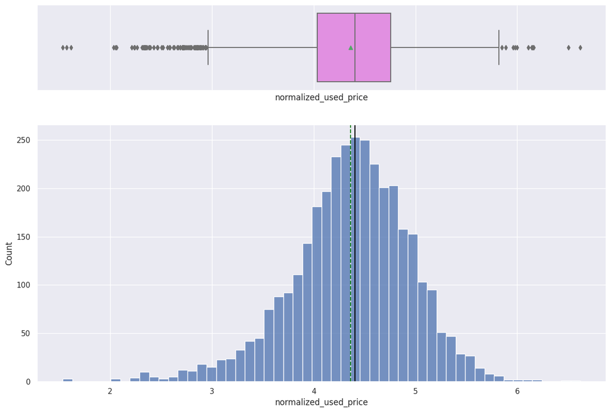

```python
histogram_boxplot(data, "normalized_used_price")
```

##### From the graph, we can see that the distribution of normalized used price is evenly distributed.

##### From the graph we can see that majority of the price for normalized used price falls within 4-5 euros

##### The graph can see some outliers from the distribution

#### Normalized New Price *Distribution*

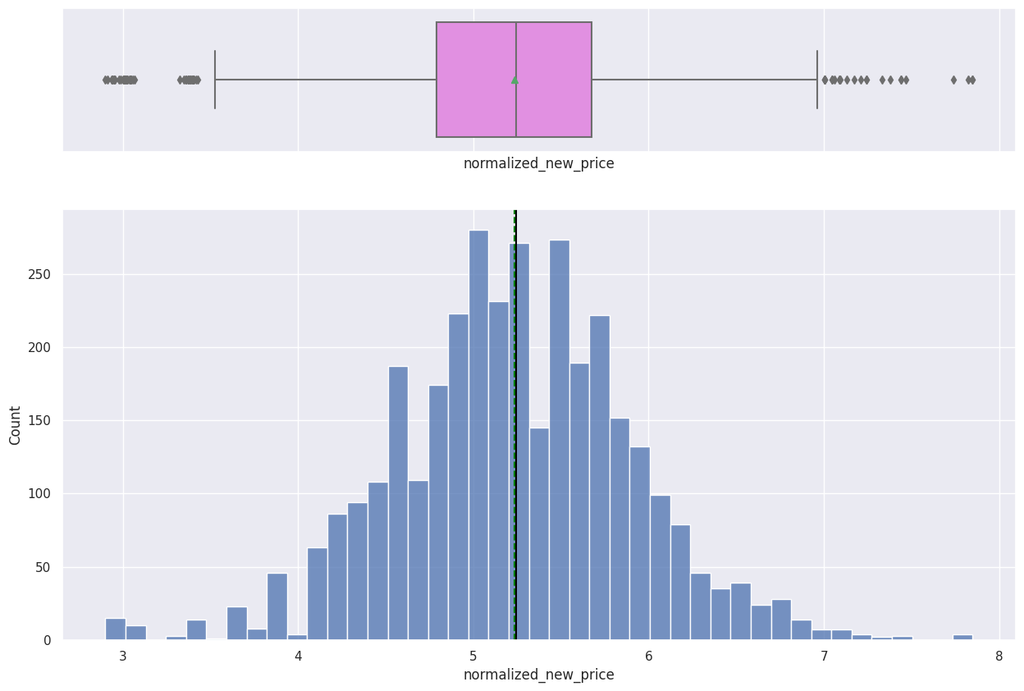

```python
histogram_boxplot(data, "normalized_new_price")
```

##### The graph appears to be close to evenly distributed

##### From the graph, we can see some outliers in the distribtion

##### Majority of the prices are within 4-6 Euros

#### Screen Size Distribution

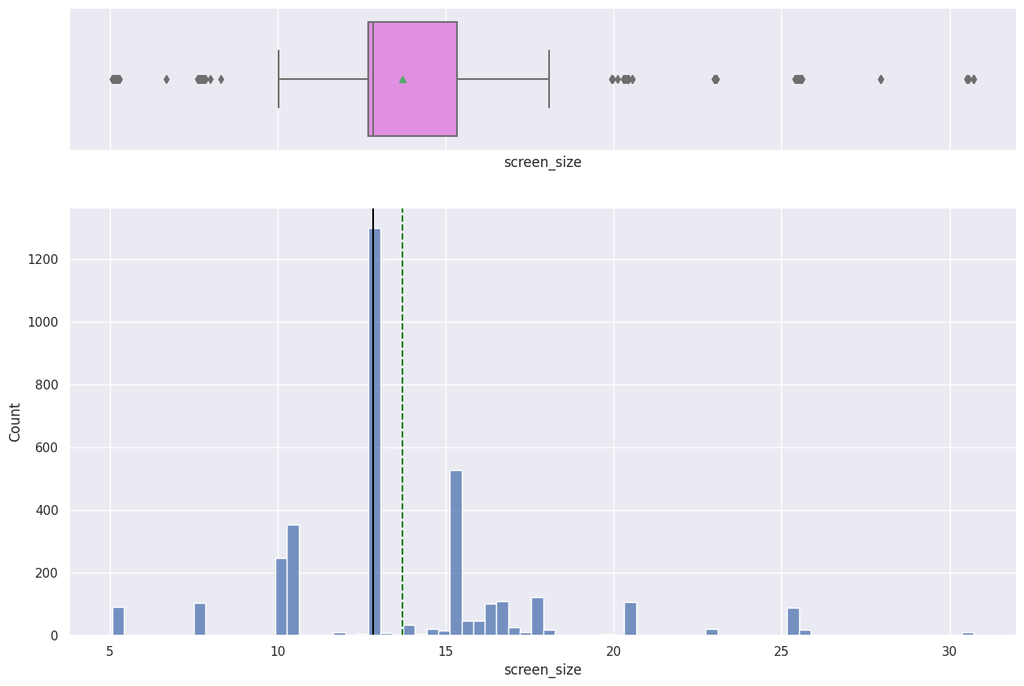

```python
histogram_boxplot(data, "screen_size")
```

##### The distribution of the screen size from the data shows that its right skewed

##### There are many outliers in the screen size distribution

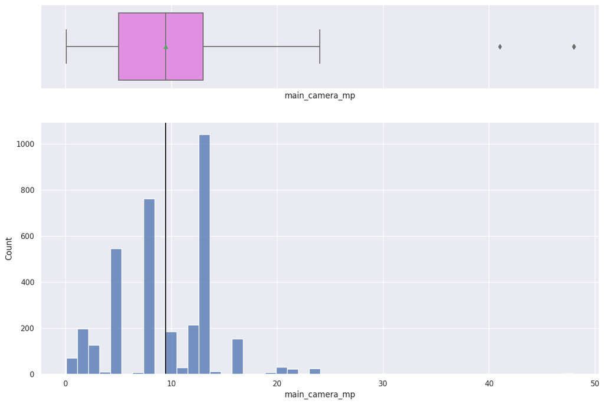

```python
#Main Camera Mp Distribution
histogram_boxplot(data, "main_camera_mp")
```

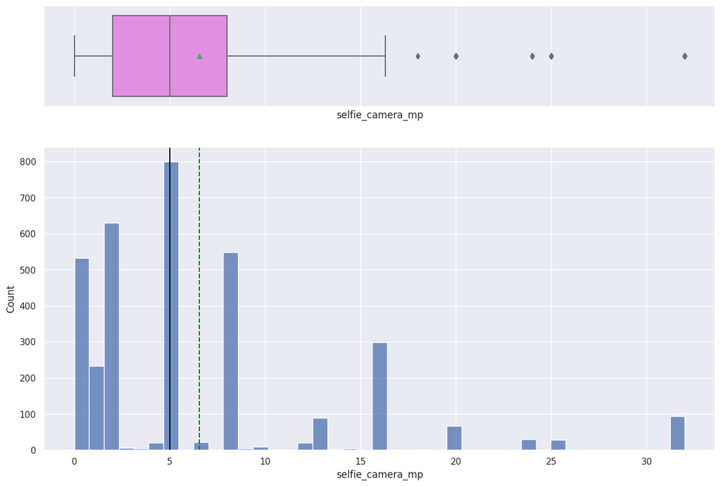

```python
#Selfie Camera Mp
histogram_boxplot(data, "selfie_camera_mp")
```

##### The selfie camera mp has some outliers

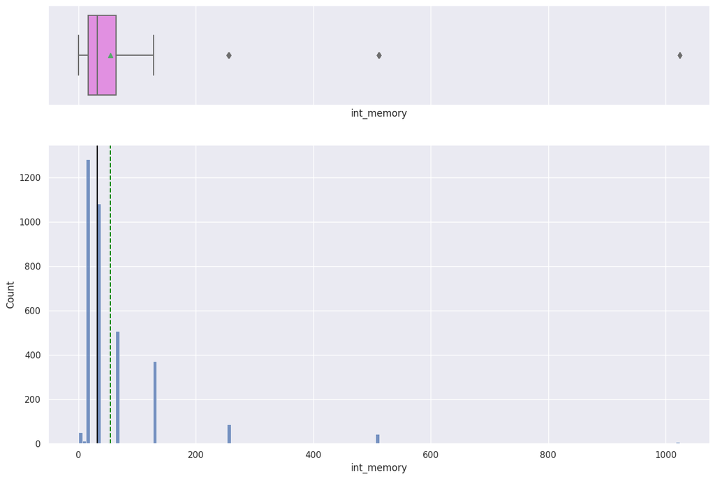

```python
#int_memory
histogram_boxplot(data, "int_memory")
```

##### The int_memory distribtion is right skewed

##### The distribution has some outliers

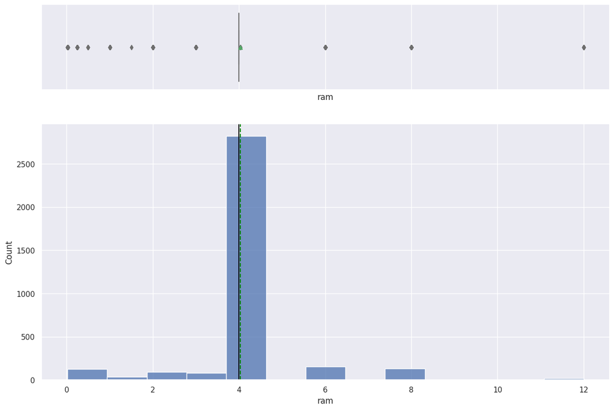

```python
#ram
histogram_boxplot(data, "ram")
```

##### The ram distribution has many outliers

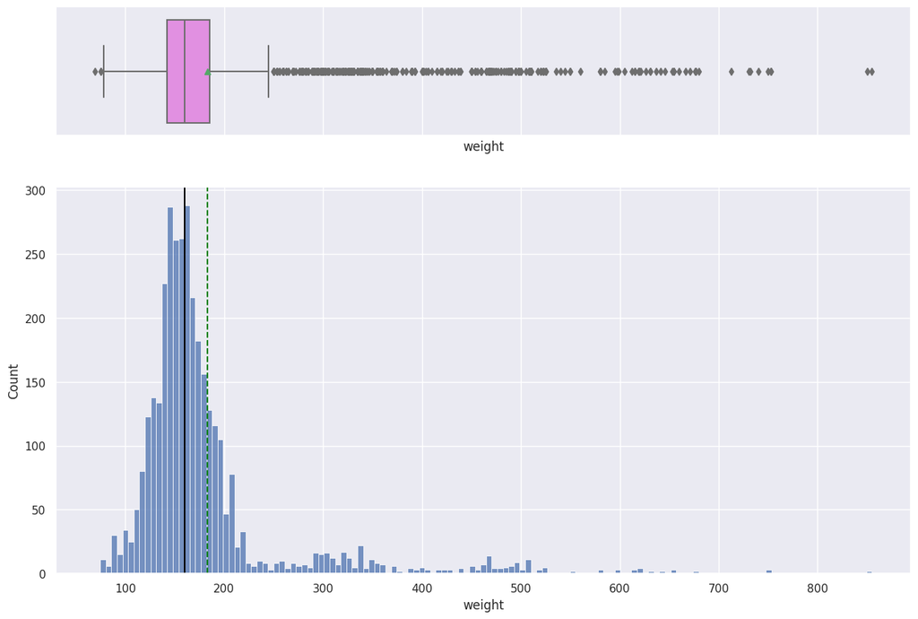

```python
#Weight
histogram_boxplot(data, "weight")
```

##### The distribution for the weight is right skewed

##### The distribution has many outliers

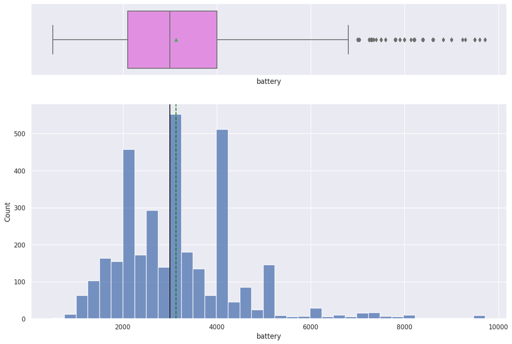

```python
#battery
histogram_boxplot(data, "battery")
```